# Quality activity recognition of six male subjects using Machine Learning

Mohamad Barad

31-01-2022

# Introduction

The data in this project is found from the following source see the link below. The aim of this assignment is to quantify how well participants are performing a weight lifting exercise based on predefined category of weightlifting modes. The classes are as follows and are more specified in [1]. So class A is the exercise performed according to the speciﬁcation. Class B is done by throwing the elbows to the front. Class C is performed by lifting the dumbbell only halfway, and Class D is lowering the dumbbell only halfway. Finally class E is done by throwing the hips to the front. So Class A represents the correct way of weight lifting while the 4 other classes are wrong ways of performing the exercise.

# Data

The data is red and from the source URLs and loaded into R for analysis

```r
# Loading training data
url_train <- "https://d396qusza40orc.cloudfront.net/predmachlearn/pml-training.csv"
download.file(url_train, destfile = "training.csv")
training <- read.csv("training.csv")
# Loading the testing data
url_test <- "https://d396qusza40orc.cloudfront.net/predmachlearn/pml-testing.csv"
download.file(url_train, destfile = "testing.csv")
testing <- read.csv("testing.csv")

# Setting seed
set.seed(2323)
```

Before carrying out with model building, data cleaning is necessary. This includes removing variables that contributes little to nothing to the dependent variable which is ‘classe’, like variables with more than 97 % of NAs and moreover empty columns are also removed.

The first 7 variables where also removed putting the focus on the sensor variables and Razor inertial measurement units.

```r
# Converting the dependent variabels to factor
training$classe <- as.factor(training$classe)

# Removing columns with NAs and empty columns
training <- training[ ,colSums(is.na(training) | training == "") == 0]
# Removing the first 7 variables
training <- training[ , -c(1:7)]
```

In order to explore some of the variables which might be used to classify the tasks, the different eurler angles were plotted against the total acceleration of the different sensors and classes (coloured) in the plots. Taking the Pitch angle as an example it is observed that class A cleary i distingued from the other classes.

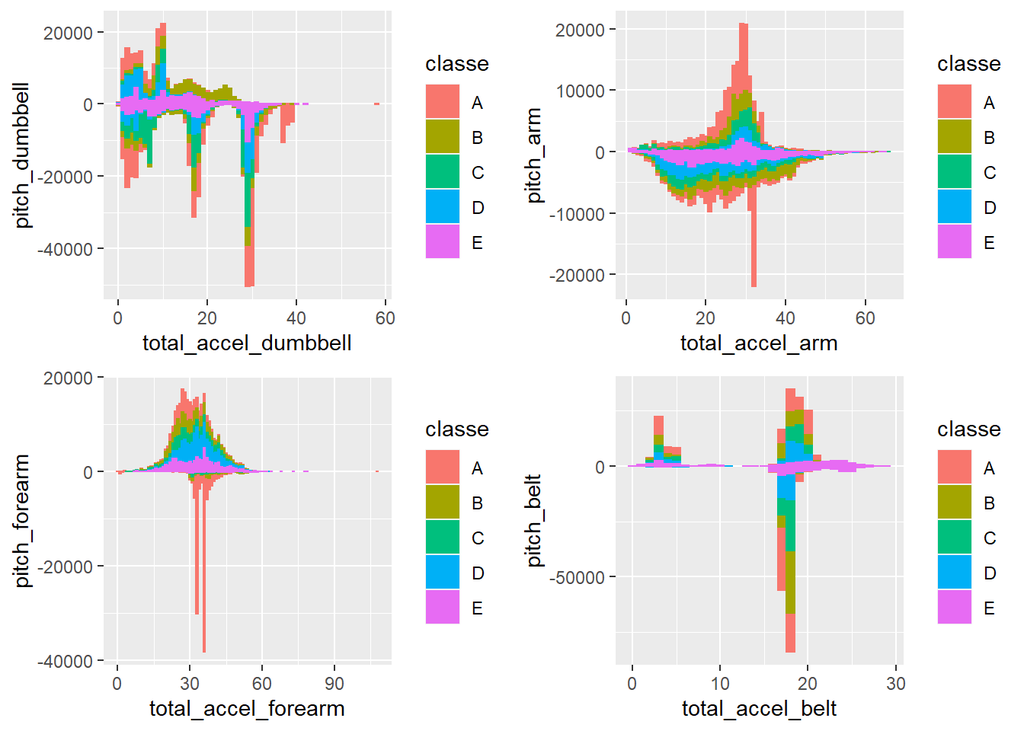

```r
# Data exploratory
library(ggplot2);library(gridExtra);library(caret)
# Pitch
p1 <- ggplot(training, aes(x = total_accel_dumbbell,y = pitch_dumbbell, fill = classe, colour = classe))+
        geom_col()
p2 <- ggplot(training, aes(x = total_accel_arm,y = pitch_arm, fill = classe, colour = classe))+
        geom_col()
p3 <- ggplot(training, aes(x = total_accel_forearm,y = pitch_forearm, fill = classe, colour = classe))+
        geom_col()
p4 <- ggplot(training, aes(x = total_accel_belt,y = pitch_belt, fill = classe, colour = classe))+
        geom_col()
grid.arrange(p1,p2,p3,p4,ncol=2)
```

Exploring some of the classes with linear fitting models and comparing those to class A in the following plots.

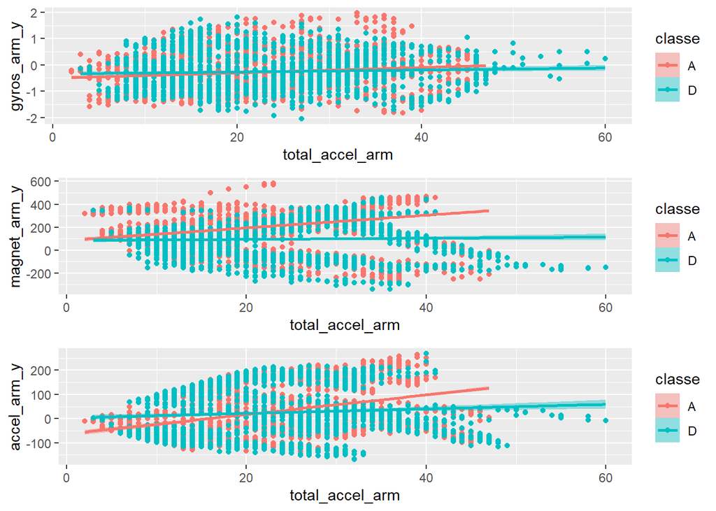

```r
p1 <- ggplot(training[which(training$classe == c("A","D")),],
             aes(y = gyros_arm_y,x = total_accel_arm, fill = classe, colour = classe))+
        geom_point()+
        geom_smooth(method = "glm")
p2 <- ggplot(training[which(training$classe == c("A","D")),],
             aes(y = magnet_arm_y, x = total_accel_arm, fill = classe, colour = classe))+
        geom_point()+
        geom_smooth(method = "glm")

p3 <- ggplot(training[which(training$classe == c("A","D")),],
             aes(y = accel_arm_y, x = total_accel_arm, fill = classe, colour = classe))+
        geom_point()+
        geom_smooth(method = "glm")
grid.arrange(p1,p2,p3,ncol=1)
```

Now it is a bit difficult to plot all 52 variables in one plot in order to see how they correlate to the 53th variable which is out dependent variable. Therefore, as an example only some of the variables are plotted and the correlations were visualised.

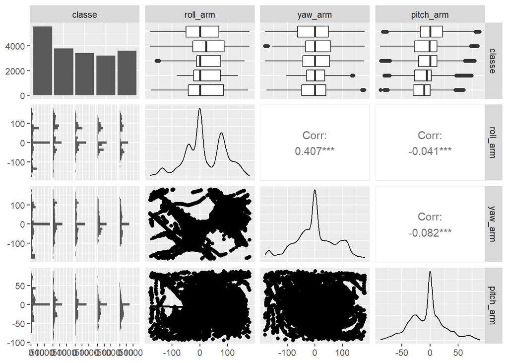

```r
library(GGally)
g <- ggpairs(training[,c("classe","roll_arm","yaw_arm","pitch_arm")], lower= list(continuous = wrap("smooth", method = "glm")))
g
```

# Machine Learning modelling

So the plan during model development is, to split training set into two parts, which allows for training one one part and modifying and testing on the other part. Then the testing set is split into a validation set and a final test set which will evaluate the overall performance of the models. The models are evaluated using the accuracy parameter. Other peratmeters could also have been used, but accuracy was used in this case.

K-nearst neighbour:

```r
# caret snippet
# Source of snippet: https://github.com/mariocastro73/ML2020-2021
train.index <- createDataPartition(training[,"classe"],p=0.75,list=FALSE)
training.trn <- training[train.index,]
training.tst <- training[-train.index,]

ctrl  <- trainControl(method  = "cv",number  = 10)

# K-nearst neighbors
knn.mod <- train(classe ~ ., data = training.trn, method = "knn",
        trControl = ctrl,
        preProcess = c("center","scale"),
        tuneGrid =data.frame(k=seq(1,5,by = 1)))
        # tuneLength = 50)

# Prediction with other part of training set
knn.pred <- predict(knn.mod,training.tst)
# Confusion matrix
knn.con.M <- confusionMatrix(table(training.tst[,"classe"],knn.pred))
```

The tree model:

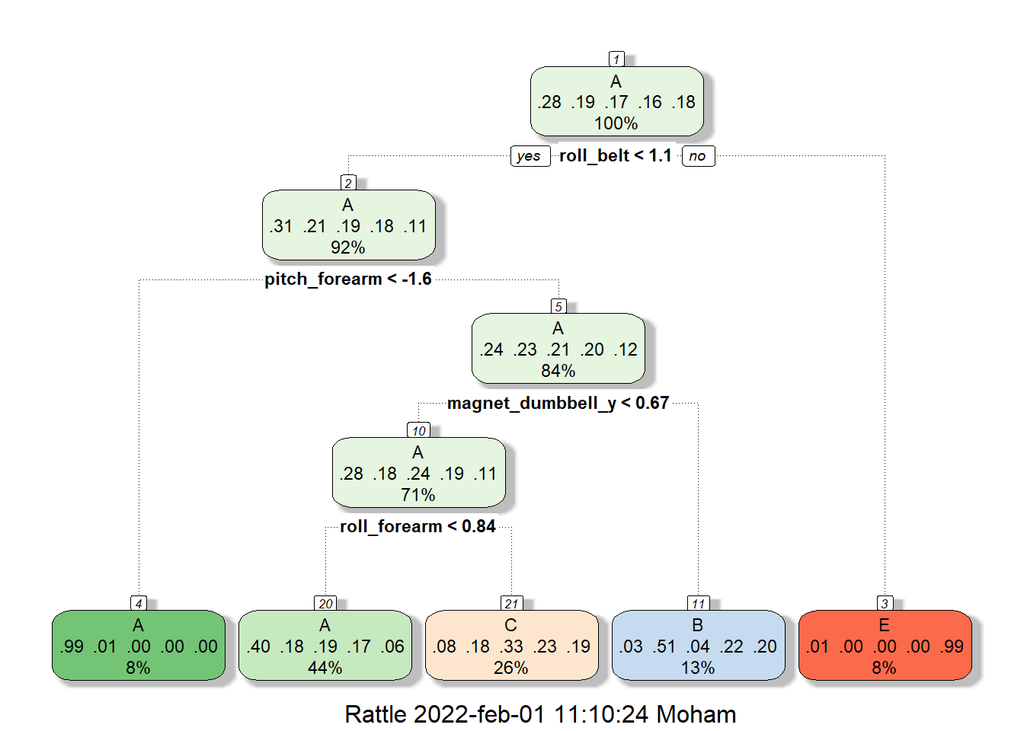

```r
# tree
tree.mod <- train(classe ~ ., data = training.trn, method = "rpart",
        trControl = ctrl,
        preProcess = c("center","scale"))

tree.pred <- predict(tree.mod,training.tst)
tree.con.M <- confusionMatrix(table(training.tst[,"classe"],tree.pred))

library(rattle)
fancyRpartPlot(tree.mod$finalModel)
```

Random Forest model:

```r
# rf
rf.mod <- train(classe ~ ., data = training.trn, method = "rf",
        trControl = ctrl,
        preProcess = c("center","scale"))

rf.pred <- predict(rf.mod,training.tst)
rf.con.M <- confusionMatrix(table(training.tst[,"classe"],rf.pred))
```

```r
# bootstrap-aggregering model
garbage <- capture.output(
gbm.mod <- train(classe ~ ., data = training.trn, method = "gbm",
        trControl = ctrl,
        preProcess = c("center","scale"))
)

gbm.pred <- predict(gbm.mod,training.tst)
gbm.con.M <- confusionMatrix(table(training.tst[,"classe"],gbm.pred))
```

```r
# Summary of training set accuracy for the 4 models
Acc.Sum.Train <- data.frame(knn = knn.con.M$overall[1],
                          tree= tree.con.M$overall[1],
                          rf = rf.con.M$overall[1],
                          gbm = gbm.con.M$overall[1])
Acc.Sum.Train
```

```
##               knn      tree        rf      gbm
## Accuracy 0.992863 0.4963295 0.9944943 0.963907
```

To visualize the different models and their accuracies as a function of different modifying parameters the following plot is presented. It is clear from the plot that the highest accuracy is achieved with the random forest model.

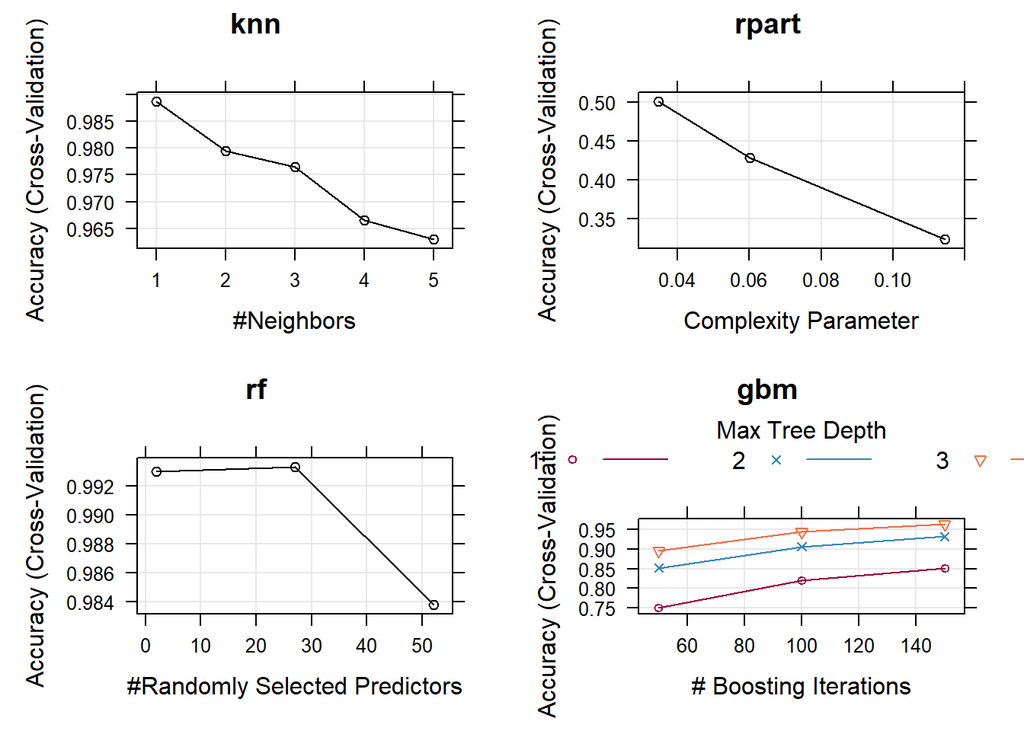

```r
library(gridExtra)
trellis.par.set(caretTheme())
p1 <- plot(knn.mod, main="knn")
p2 <- plot(tree.mod, main="rpart")
p3 <- plot(rf.mod, main="rf")
p4 <- plot(gbm.mod, main="gbm")
grid.arrange(p1,p2,p3,p4, ncol = c(2))
```